# Lab 1: Parte 2

Helder Machado de Lima

```r
atividade = read_projectdata()
polititicos_filter = atividade %>% filter(!is.na(twitter) & !is.na(seguidores) & !is.na(segue))
```

## P1: De quais estados são os congressistas com maior engajamento de retweets?

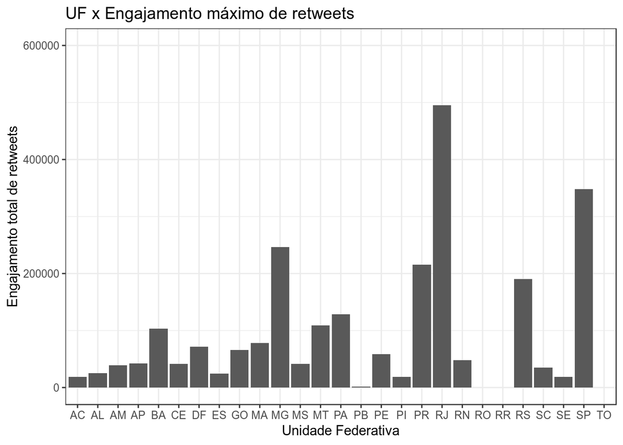

```r
options(scipen = 999)
polititicos_filter %>% ggplot(aes(x = UF, y = engaj_max_retweet, yend=600000,scipen = 999, format(y, scientific = FALSE))) + geom_col() +
  labs(title="UF x Engajamento máximo de retweets",
       y="Engajamento total de retweets",
       x="Unidade Federativa")
```

### Resposta: SP, SJ, MG, PR, RS

## Pergunta derivada da P1: O engajamento próprio se mantem na maioria dos casos?

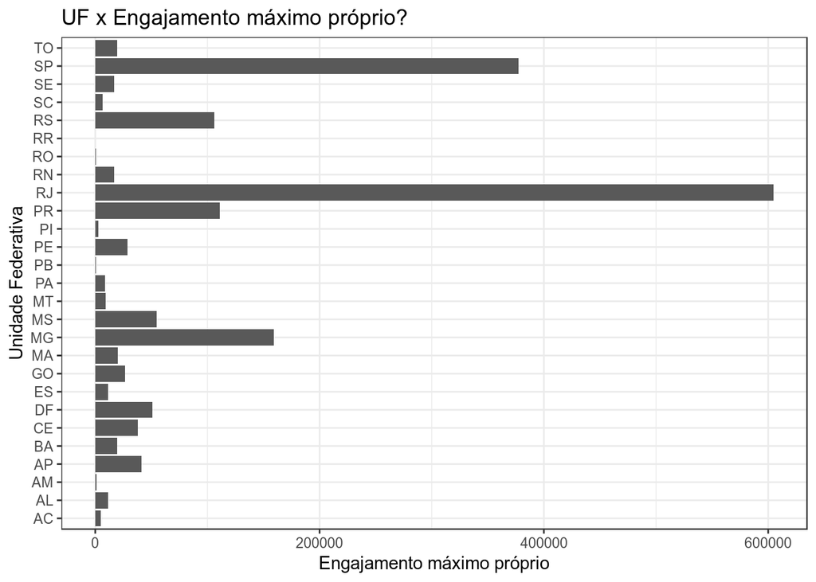

```r
polititicos_filter %>% ggplot(aes(x = UF, y = engaj_max_proprio)) + geom_col() + coord_flip()+
  labs(title="UF x Engajamento máximo próprio?",
       y="Engajamento máximo próprio",
       x="Unidade Federativa")
```

### Resposta: Na maioria dos casos sim, mas tomando o PA como exemplo, podemos perceber que há casos em que o engajamento vem basicamente dos retweets e não dos congressista do partido.

## P2: Maior engajamento significa maior número de seguidores?

### O escopo foi reduzido para uma melhor visualização

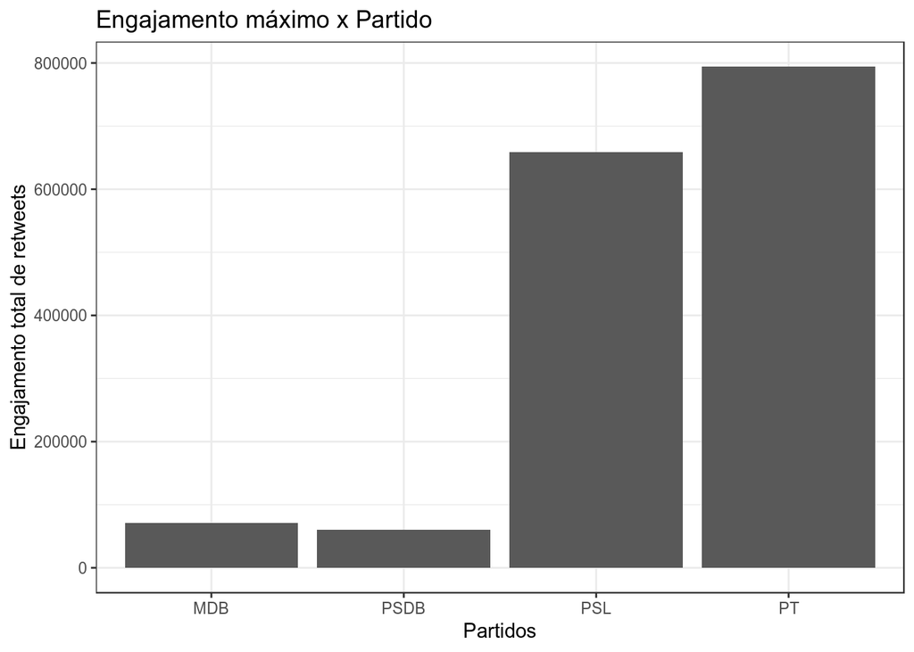

```r
polititicos_filter %>% filter(partido == "PSL" | partido == "PT" | partido == "MDB"| partido == "PSDB") %>% ggplot(aes(x = partido , y=engaj_max)) + geom_col() +
  labs(
    title="Engajamento máximo x Partido",
    y="Engajamento total de retweets",
    x="Partidos")
```

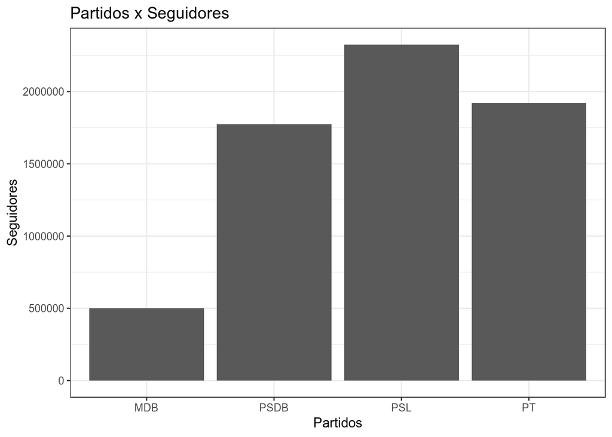

```r
polititicos_filter %>% filter(partido == "PSL" | partido == "PT"| partido == "MDB"| partido == "PSDB") %>% ggplot(aes(x = partido , y=seguidores)) + geom_col() +
  labs(
    title="Partidos x Seguidores",
    y="Seguidores",
    x="Partidos")
```

### Resposta: Em grande maioria sim, mas existem anomalias como o do PSDB que o engajamento baixo não está relacionado com um baixo número de seguidores, pelo contrário, eles possuem um alto número de seguidores.

## Pergunta derivada da P2: O número de seguidores tem influência no número de tweets dos parlamentares?

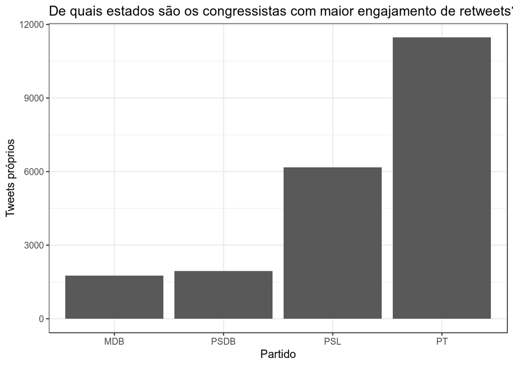

```r
polititicos_filter %>% filter(partido == "PSL" | partido == "PT"| partido == "MDB"| partido == "PSDB") %>% ggplot(aes(x = partido , y=n_proprio)) + geom_col() +
  labs(
    title="De quais estados são os congressistas com maior engajamento de retweets?",
    x="Partido",
    y="Tweets próprios")
```

## Resposta: Neste caso é possível perceber que o PT tem menos seguidores e mesmo assim tem um maior engajamento e os parlamentares apresentam um número alto de tweets dos congressistas, já o PSDB segue a na contramão de e mesmo com muitos seguidores, não conseguem ter um alto número de retweets, pelos visto parece ser por não se mostrarem tão presentes no estado político atual.